# Modèle linéaire multiple

2eme-FA-EMS - BUT SD - E. Anakok

```r
library(tidyverse)
library(extrafont)
require(ggsci)
library(ggpubr)
library(knitr)
library(ggfortify)
library(ggrepel)
```

## 0.1 Problématique biologique

**WarningObjectif**

- Peut-on prédire le poids des poissons par leurs largeurs, leurs longueurs et leurs épaisseurs ?
- Tester le caractère significatif de la liaison : Y’a t’il un lien significatif entre le poids des poissons et leurs largeurs, leurs longueurs et leurs épaisseurs ?
- Y’a t’il un lien entre le poids du poisson et sa largeur après avoir pris en compte sa longueur et son epaisseur ?
- **Données** On a pour 20 brèmes péchées dans le lac Laengelmavesi en Finland leurs poids (en gramme) et leurs longeurs (en cm), leurs largeurs (en cm) leurs épaisseur (en cm).

[figure not shown]

# 1 Écriture et remarque sur le modèle

## 1.1 Écriture du modèle

#### 1.1.0.1 Notations

On a $n = 20$ observations. On note, pour $1 \leq i \leq 20$

- $x_{1,i}$ la mesure de la longueur du poisson $i$.
- $x_{2,i}$ la mesure de la largeure du poisson $i$.
- $x_{3,i}$ la mesure de l’epaisseur du poisson $i$.
- $y_i$ la mesure du poids du poisson $i$.

**NoteDéfinition : Modèle de régression linéaire multiple**

On suppose que $y_i$ est la réalisation d’une variable aléatoire $Y_i$ telle que:
$$Y_i = \alpha_1 x_{1,i} + \alpha_2 x_{2,i} + \alpha_3 x_{3,i} + \beta + E_i,\quad 1 \leq i \leq n$$

- $\alpha_1$ (resp $\alpha_2$ , $\alpha_3$ ) est un paramètre inconnu, l’effet de la longueur (resp largeur, épaisseur) sur le poids;
- $\beta$ est un paramètre inconnu;
- $E_i$ une variable aléatoire, $E_i \overset{i.i.d.}\sim \mathcal{N}(0, \sigma^2)$
- Les $x_i$ sont linéairement indépendants

## 1.2 Écriture plus générale du modèle

#### 1.2.0.1 Notations

On a $n = 20$ observations. On note, pour $1 \leq i \leq 20$

- $x_{1}, \dots, x_{p}$, $p$ variables explicatives et $y$ une variable réponse
- $y_i$ la mesure de la variable réponse de l’individu $i$.
- $\forall j \in \{ 1,\dots, p \}$, $x_{j,i}$ la valeur de la variable $x_j$ de l’individu $i$

**NoteDéfinition : Modèle de régression linéaire multiple**

On suppose que $y_i$ est la réalisation d’une variable aléatoire $Y_i$ telle que:
$$Y_i = \sum_{j=1}^p \alpha_j x_{j,i} + \beta + E_i,\quad 1 \leq i \leq n$$

- $\alpha_j$ est un paramètre inconnu, l’effet de la variable $x_j$ sur le y;
- $\beta$ est un paramètre inconnu
- $E_i$ une variable aléatoire, $E_i \overset{i.i.d.}\sim \mathcal{N}(0, \sigma^2)$
- Les $x_i$ sont linéairement indépendants (en pratique vérifier avec le VIF)

## 1.3 Deux écritures équivalentes

**CautionRemarques**

Les deux modèles suivant sont équivalent :

- $\forall i \in \{1, \dots, n\} \;\;$

$$Y_i = \sum_{j=1}^p \alpha_j x_{j,i} + \beta + E_i,\quad \ E_i \overset{i.i.d.}\sim \mathcal{N}(0, \sigma^2)$$

- $\forall i \in \{1, \dots, n\} \;\;$

$$Y_i \overset{i.i.d.}\sim \mathcal{N}\left(\sum_{j=1}^p \alpha_j x_{j,i} + \beta, \sigma^2\right)$$

## 1.4 Dans l’exemple des poissons

**CautionRemarques**

Les deux modèles suivant sont équivalent :

- $\forall i \in \{1, \dots, n\} \;\;$
  $$Y_i = \alpha_1 x_{1,i} + \alpha_2 x_{2,i} + \alpha_3 x_{3,i} + \beta + E_i,\quad \ E_i \overset{i.i.d.}\sim \mathcal{N}(0, \sigma^2)$$
- $\forall i \in \{1, \dots, n\} \;\;$
  $$Y_i \overset{i.i.d.}\sim \mathcal{N}\left(\alpha_1 x_{1,i} + \alpha_2 x_{2,i} + \alpha_3 x_{3,i} + \beta, \sigma^2\right)$$

## 1.5 Remarques sur les paramètres

**CautionRemarques**

Dans le modèle $\forall i \in \{1, \dots, n\} \;\;$
$$Y_i = \sum_{j=1}^p \alpha_j x_{j,i} + \beta + E_i,\quad\ E_i \overset{i.i.d.}\sim \mathcal{N}(0, \sigma^2)$$

- $\alpha_j$ représente l’accroissement de $Y_i$ correspondant à l’accroissement d’une unité sur $x_j$ si les autres variables explicatives sont fixées. Dans l’exemple des poissons : $\alpha_1$ represente l’accroissement du poids correspondant à l’accroissement d’1 cm sur la longeurs du poisson si la largeur et l’épaisseur son fixé.
- Ce modèle est de dimension $p + 1$. (Avec $p+1$ paramètres d’espérance à estimer $p$ pour $\alpha$ et $1$ pour$\beta$)
- $\forall i \in \{1, \dots, n\}$ $Y_i$ se décompose en $\color{red}{Y_i} = {\color{blue}{\underbrace{\displaystyle\sum_{j=1}^p \alpha_j x_{j,i} + \beta}_{{déterministe}{}}}} + \color{red}{\overbrace{E_i}^{aléatoire}}$

# 2 Écriture matricielle du modèle

## 2.1 Rappel sur les matrices

1. Qu’est ce qu’une matrice ?
2. La multiplication matricielle
3. La transposée d’une matrice
4. L’inverse d’une matrice
5. Petits topo sur les vecteurs

## 2.2 Rappels d’algèbre

**NoteRappel : Matrice**

$A = (a_{i,j})_{1\leq i \leq p, 1\leq j \leq q}$ est une **matrice** à coefficients réels de format $(p \times q)$

$$A = \begin{bmatrix}
a_{11} & a_{12} & \ldots & a_{1q}\\
a_{21} & a_{22} & \ldots & a_{2q}\\
\vdots & \vdots & & \vdots \\
a_{p1} & a_{p2} & \ldots & a_{pq}
\end{bmatrix}$$

**NoteRappel : Transposée d’une matrice**

Si $A = (a_{i,j})_{1\leq i \leq p, 1\leq j \leq q}$ est une matrice $(p \times q)$, on note alors $A^t$ sa **transposée**, la matrice $(q \times p)$ définie par

$$A^t = \begin{bmatrix}
a_{11} & a_{21} & \ldots & a_{p1}\\
a_{12} & a_{22} & \ldots & a_{p2}\\
\vdots & \vdots & & \vdots \\
a_{1q} & a_{2q} & \ldots & a_{pq}
\end{bmatrix}$$

**NoteRappel : Matrice symétrique**

$A$ est une **matrice symétrique** si :

- $A$ est une matrice carré ($p=q$)
- $A^t = A$

**NoteRappel : Transposée du produit**

Soit $A$ et $B$ deux matrices. On a

$$(A B)^t = B^t A^t$$

## 2.3 Rappels d’algèbre : Vecteur

**NoteRappel : Vecteurs**

- On note V un **vecteur** à $p$ éléments par

$$V = \begin{bmatrix} v_{1} \\ v_{2}\\ \vdots \\ v_{p} \end{bmatrix}= \left[{v_1, v_2, \ldots, v_p}\right]^t$$

## 2.4 Rappels d’algèbre : Vecteur

**NoteRappel : Produit matrice-vecteur**

Si $V$ est un vecteur à $q$ éléments et $A$ une matrice $(p \times q)$ alors, $U=AV$ est un vecteur à $p$ éléments

$$\begin{bmatrix} u_{1} \\ u_{2}\\ \vdots \\ u_{p} \end{bmatrix} = AV =
\begin{bmatrix}
a_{11} & a_{12} & \ldots & a_{1q}\\
a_{21} & a_{22} & \ldots & a_{2q}\\
\vdots & \vdots & & \vdots \\
a_{p1} & a_{p2} & \ldots & a_{pq}
\end{bmatrix}\begin{bmatrix} v_{1} \\ v_{2}\\ \vdots \\ v_{p} \end{bmatrix} = \begin{bmatrix} \sum_{j=1}^{q} a_{1j} v_j \\ \sum_{j=1}^{q} a_{2j} v_j\\ \vdots \\
\sum_{j=1}^{q} a_{pj} \end{bmatrix}$$

## 2.5 Rappels d’algèbre : Identité et inverse

**NoteRappel : matrice identité**

La matrice **identité** $I_n$ est la matrice carré à $n$ lignes et $n$ colonnes, dont les coefficients diagonaux valent $1$ et les autres valent $0$.

$$I_n = \begin{bmatrix}
1 & 0 & \ldots & 0\\
0 & 1 & \ldots & 0\\
\vdots & \vdots & & \vdots \\
0 & 0 & \ldots & 1
\end{bmatrix}$$

**NoteRappel : Inverse d’une matrice**

Si $A = (a_{i,j})_{1\leq i \leq p, 1\leq j \leq p}$ est une matrice carrée $(p \times p)$ **inversible**, alors on note son **inverse** $A^{-1}$ la matrice $(p \times p)$ telle que

$$A\,A^{-1} = A^{-1}\,A = I_p$$

**NoteRappel : Transposée de l’inverse**

Si $A$ est une matrice inversible, alors

$$(A^{-1})^t=(A^t)^{-1}$$

## 2.6 Vecteurs aléatoires

**NoteRappel : Vecteurs aléatoires**

Soient $V_1,V_2,\dots,V_n$, $n$ variables aléatoires réelles, alors

$$V = \begin{bmatrix} V_1 \\ V_2 \\ \vdots \\ V_n \end{bmatrix}$$

**NoteRappel : Espérance d’un vecteur aléatoire**

$V$ a pour **espérance**

$$\mathbb{E}[V] = \begin{bmatrix} \mathbb{E}[V_1] \\ \mathbb{E}[V_2] \\ \vdots \\ \mathbb{E}[V_n] \end{bmatrix}$$

**NoteRappel : Matrice de variance-covariance**

$V$ a pour matrice de **variance-covariance** (symétrique)

$$\mathbb{V}[V] = \mathbb{E}\left[\left(V- \mathbb{E}[V] \right)\left(V- \mathbb{E}[V] \right)^t \right] =$$

$$\begin{bmatrix} \mathbb{V}[V_1] & cov(V_1,V_2) & \dots& Cov(V_1,V_n) \\
cov(V_2,V_1) & \mathbb{V}[V_2] & \dots& Cov(V_2,V_n) \\
\vdots & \vdots & \ddots & \vdots \\
cov(V_n,V_1) & cov(V_n,V_2) & \dots& \mathbb{V}[V_n]\end{bmatrix}$$

## 2.7 Propriétés

**TipThéorème**

Soient $\color{blue}{A}$ et $\color{blue}{B}$ des matrices à coefficients non aléatoires et soit $\color{red}{V}$ un vecteur aléatoire, alors

$$\begin{align}
\mathbb{E}[\color{blue}{A}\color{red}{V}\color{blue}{B}] &= \color{blue}{A} \mathbb{E}[\color{red}{V}]\color{blue}{B}\\
\mathbb{V}[\color{blue}{A}\color{red}{V}] & = \color{blue}{A} \mathbb{V}[\color{red}{V}] \color{blue}{A^t}
\end{align}$$

**NoteRappel : Vecteurs gaussiens**

Si $V_1, V_2, \ldots, V_n$ sont gaussiennes et indépendantes, alors $V = [V_1, \ldots, V_n]^t$ est **un vecteur gaussien**.

Si $V_1, V_2, \ldots, V_n \overset{i.i.d}\sim \mathcal{N}(0,\sigma ^2)$, alors

$$V \sim \mathcal{N}\left(\vec{0}_n,\,\sigma^2 I_n\right)$$
où $I_n$ est la matrice identité d’ordre $n$.

## 2.8 Écriture matricielle du modèle

**TipThéorème**

$$\left\{\begin{matrix}
Y_1 = \beta\ +\ \alpha_1\,x_{1,1}\ +\ \alpha_2\,x_{2,1}\ +\
\ldots\ +\ \alpha_{p}\,x_{p, 1}\ +\ E_1\\
Y_2 = \beta\ +\ \alpha_1\,x_{1, 2}\ +\ \alpha_2\,x_{2,2}\ +\
\ldots\ +\ \alpha_{p}\,x_{p, 2}\ +\ E_2\\
\vdots \\
Y_n = \beta\ +\ \alpha_1\,x_{1,n}\ +\ \alpha_2\,x_{2, n}\ +\
\ldots\ +\ \alpha_{p}\,x_{p,n}\ +\ E_n \end{matrix} \right.$$

peut se réécrire sous la forme

$$Y = X \theta + E$$

avec

$$Y =\begin{bmatrix} Y_1\\ Y_2\\ \vdots \\ Y_n\end{bmatrix},\quad X = \begin{bmatrix}
1 & x_{1,1} & \ldots & x_{p, 1}\\
1 & x_{1, 2} & \ldots & x_{p, 2}\\
\vdots & \vdots & & \vdots \\
1 & x_{1, n} & \ldots & x_{p, n}
\end{bmatrix},\quad \theta = \begin{bmatrix} \beta\\ \alpha_1\\
\alpha_2\\ \vdots \\ \alpha_{p}\end{bmatrix},\quad E = \begin{bmatrix}E_1\\
E_2\\ \vdots \\ E_n\end{bmatrix}$$

## 2.9 Écriture matricielle du modèle

**TipPropriété**

- $X$ est de taille $n\times (p+1)$
- $\theta$ est de dimension $(p+1)\times 1$ : vecteur des paramètres d’espérance
- $E$ est de dimension $(n\times 1)$ : est un vecteur Gaussien tel que

$$E \sim \mathcal{N}\left(\vec{0}_n,\,\sigma^2 I_n\right)$$

- $Y$ est de dimension $(n\times 1)$ : est un vecteur Gaussien tel que

$$Y \sim \mathcal{N}\left(X\theta,\,\sigma^2 I_n\right)$$

**CautionRemarques**

Si les vecteurs colonnes de $X$ sont linéairement indépendants, $X$ est de rang $p+1$ et $X^t X$ est inversible.

## 2.10 Exercice : écrire le modèle linéaire univarié sous forme matricielle

## 2.11 Correction

Le modèle de régression simple
$$Y_i=\alpha x_i+\beta+E_i$$
s’écrit matriciellement $Y=X\theta+E$ avec
$$Y = \begin{bmatrix} Y_1\\ Y_2\\ \vdots \\ Y_n\end{bmatrix},\quad
X = \begin{bmatrix}
1 & x_{1} \\
1 & x_{2} \\
\vdots & \\
1 & x_{n} \\
\end{bmatrix},\quad
\theta\ =\ \begin{bmatrix}\beta\\ \alpha\end{bmatrix},\quad
E\ =\ \begin{bmatrix} E_1\\
E_2\\ \vdots \\ E_n\end{bmatrix}$$

## 2.12 Écriture du modèle linéaire simple

**TipPropriété**

- $X$ est de taille $(n\times 2)$
- $\theta$ est de dimension $(2 \times 1)$ : vecteur des paramètres d’espérance
- $E$ est de dimension $(n\times 1)$ : est un vecteur Gaussien tel que

$$E \sim \mathcal{N}\left(\vec{0}_n,\,\sigma^2 I_n\right)$$

- $Y$ est de dimension $(n\times 1)$ : est un vecteur Gaussien tel que

$$Y \sim \mathcal{N}\left(X\theta,\,\sigma^2 I_n\right)$$

**CautionRemarques**

Si les $x_i$ ne sont pas tous égaux, les deux vecteurs colonnes de $X$ sont linéairement indépendants et $X$ est de rang $p = 2$.

## 2.13 Exemple sur les poissons

#### 2.13.0.1 Notations

On a $n = 20$ observations. On note, pour $1 \leq i \leq 20$

- $x_{1,i}$ la mesure de la longueur du poisson $i$.
- $x_{2,i}$ la mesure de la largeure du poisson $i$.
- $x_{3,i}$ la mesure de l’epaisseur du poisson $i$.
- $y_i$ la mesure du poids du poisson $i$.

**NoteDéfinition : Modèle de régression linéaire multiple**

On suppose que $y_i$ est la réalisation d’une variable aléatoire $Y_i$ telle que:
$$Y_i = \alpha_1 x_{1,i} + \alpha_2 x_{2,i} + \alpha_3 x_{3,i} + \beta + E_i,\quad 1 \leq i \leq n$$

- $\alpha_1$ (resp $\alpha_2$ , $\alpha_3$ ) est un paramètre inconnu, l’effet de la longueur (resp largeur, épaisseur) sur le poids;
- $\beta$ est un paramètre inconnu;
- $E_i$ une variable aléatoire, $E_i \overset{i.i.d.}\sim \mathcal{N}(0, \sigma^2)$
- Les $x_i$ sont linéairement indépendants

## 2.14 Comment écrire le modèle :

$$\left\{\begin{matrix}
Y_1 = \beta\ +\ \alpha_1\,x_{1,1}\ +\ \alpha_2\,x_{2,1}\
+\ \alpha_{3}\,x_{3, 1}\ +\ E_1\\
Y_2 = \beta\ +\ \alpha_1\,x_{1, 2}\ +\ \alpha_2\,x_{2,2}\ +\
\alpha_{3}\,x_{3, 2}\ +\ E_2\\
\vdots \\
Y_n = \beta\ +\ \alpha_1\,x_{1,n}\ +\ \alpha_2\,x_{2, n}\ +\
\alpha_{3}\,x_{3,n}\ +\ E_n \end{matrix} \right.$$

peut se réécrire sous la forme

$$Y = X \theta + E$$

avec

$$Y =\begin{bmatrix} Y_1\\ Y_2\\ \vdots \\ Y_n\end{bmatrix},\quad X = \begin{bmatrix}
1 & x_{1,1} & x_{2,1} & x_{3, 1}\\
1 & x_{1, 2} & x_{2,1} & x_{3, 2}\\
\vdots & \vdots & & \vdots \\
1 & x_{1, n} & x_{2,1} & x_{3, n}
\end{bmatrix},\quad \theta = \begin{bmatrix} \beta\\ \alpha_1\\
\alpha_2\\ \alpha_{3}\end{bmatrix},\quad E = \begin{bmatrix}E_1\\
E_2\\ \vdots \\ E_n\end{bmatrix}$$

## 2.15 Avec les données :

$$X =$$

| Intercept | Length1 | Height | Width |
| --- | --- | --- | --- |
| 1 | 23.2 | 11.5200 | 4.0200 |
| 1 | 24.0 | 12.4800 | 4.3056 |
| 1 | 23.9 | 12.3778 | 4.6961 |
| 1 | 26.3 | 12.7300 | 4.4555 |
| 1 | 26.5 | 12.4440 | 5.1340 |
| 1 | 26.8 | 13.6024 | 4.9274 |
| 1 | 26.8 | 14.1795 | 5.2785 |
| 1 | 27.6 | 12.6700 | 4.6900 |
| 1 | 27.6 | 14.0049 | 4.8438 |
| 1 | 28.5 | 14.2266 | 4.9594 |

# 3 Estimation des paramètres d’espérance du modèle

## 3.1 Estimateurs des moindres carrés

**WarningObjectif**

On note $\theta= [\beta,\alpha_1,...,\alpha_p]^t$.

Comme dans la regression linéaire simple on cherche à minimiser :

$$J(\theta) = \sum_{i = 1}^n \left( y_i -(\beta + \sum_{j=1}^p \alpha _j x_{j,i}) \right)^2$$
Écriture matricielle ?

## 3.2 Rappels d’algèbre : norme

**NoteRappel : norme**

Soit
$$V\ =\ \begin{bmatrix} v_{1} \\ v_{2}\\ \vdots \\ v_{n}\end{bmatrix}
\ =\ [v_1, \ldots, v_n]^t$$
un vecteur de $\mathbb{R}^n$. On appelle norme de $V$ le réel

$$\displaystyle V^t V \ =\ \sum_{i=1}^{n} v_i^2\ =\ ||V||^2$$

**CautionRemarque**

$$V^t V \neq V V^t$$

$$V V^t = \begin{bmatrix} v_1^2 & v_1\,v_2 & \ldots & v_1\,v_n\\
v_2\,v_1 & v_2^2 & \ldots & v_2\,v_n\\
\vdots & \vdots & & \vdots \\
v_n\,v_1 & v_n\,v_2 & \ldots & v_n^2 \end{bmatrix}$$

## 3.3 Estimateurs des moindres carrés

**WarningObjectif**

On souhaite trouver $\theta= (\beta,\alpha_1,...\alpha_p)^t$ qui minimise

$$J(\theta)=\sum_{i = 1}^n \left( y_i -(\beta + \sum_{j=1}^p \alpha _j x_{j,i}) \right)^2 = (Y-X\theta)^t(Y-X\theta) = ||Y-X\theta||^2$$

**TipThéorème**

Le $\theta$ optimal est la solution du système de $p+1$ équations à $p+1$ inconnues

$$\left\{\begin{array}{ccc}
\frac{\partial \sum_{i = 1}^n \left( y_i -(\beta + \sum_{j=1}^p \alpha _j x_{j,i}) \right)^2 }{\partial \beta} & = & 0 \\
%
\frac{\partial \sum_{i = 1}^n \left( y_i -(\beta + \sum_{j=1}^p \alpha _j x_{j,i}) \right)^2 }{\partial \alpha_1} & = & 0\\
\vdots & & \\
\frac{\partial \sum_{i = 1}^n \left( y_i -(\beta + \sum_{j=1}^p \alpha _j x_{j,i}) \right)^2 }{\partial \alpha_p} & = & 0
\end{array}\right.$$

## 3.4 À la recherche de $\widehat{\theta}$

$$\widehat{\theta} = \underset{\theta\in\mathbb{R}^{p+1}}{argmin} (Y-X\theta)^t(Y-X\theta) =\underset{\theta\in\mathbb{R}^{p+1}}{argmin} ||Y-X\theta||^2$$

$\widehat{\theta} = [B,A_1, \dots, A_p]^t$ où $B$ est l’estimateur de $\beta$ et $A_j$ l’estimateur de $\alpha_j$

En dérivant par rapport à $\theta$ on obtient :
$$-2Y^tX + 2\theta^tX^tX$$
Le système $-2Y^tX + 2\theta^tX^tX=0$ est bien le même que les $p+1$ equations de la slide précédente

## 3.5 À la recherche de $\widehat{\theta}$

$$\begin{align}
-2Y^tX + 2\widehat{\theta}^tX^tX = 0 &\iff \widehat{\theta}^tX^tX = Y^tX \\
\iff X^tX \widehat{\theta} = X^tY & \iff \widehat{\theta} = (X^tX)^{-1} X^tY
\end{align}$$

**CautionRemarques**

$X$ est de rang $p+1$ donc $X^tX$ est inversible.

**TipThéorème**

$$\widehat{\theta} =\underset{\theta\in\mathbb{R}^{p+1}}{argmin} ||Y-X\theta||^2$$
a pour solution

$$\widehat{\theta} = (X^tX)^{-1} X^tY$$

## 3.6 Estimateurs des paramètres d’espérance

**WarningObjectif : Estimateur des moindres carrés de $\theta$**

$$\widehat{\theta} =\underset{\theta\in\mathbb{R}^{p+1}}{argmin} ||Y-X\theta||^2$$

**TipThéorème**

- Si $\hat{\theta}= [B, A_1, \ldots, A_{p}]^t$ est solution du système et que $(X^t\,X)$ est inversible, alors

$$\hat{\theta}=(X^t\,X)^{-1}\,X^t\,Y$$

| Paramètres | Estimateurs | Estimations |
| --- | --- | --- |
| $[\beta,\alpha_1,...\alpha_p]$ | $[B, A_1, \ldots, A_{p}]$ | $[b,a_1,\cdots,a_p]$ |

# 4 Validation des hypothèses et estimation avec R

## 4.1 Les 4 graphiques

```r
fish <- read.table(file = "Fish.csv",
                   sep =",", header = TRUE) %>% filter(Species == "Bream")
```

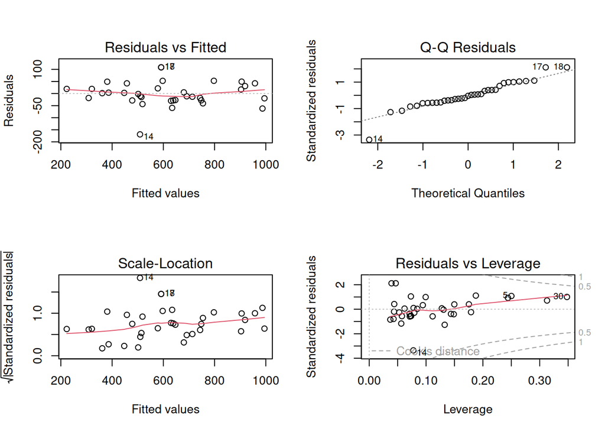

```r
mod <- lm(Weight ~Length1 + Height + Width , data =  fish)
par(mfrow=c(2,2))
plot(mod)
```

## 4.2 Multicolinéarité des $x_i$

On vérifie la corrélation entre les $x_i$

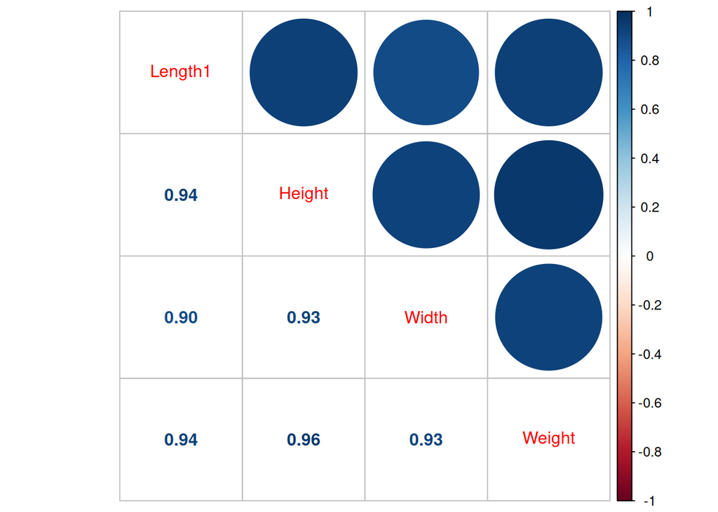

```r
library(corrplot)
M = cor(fish[c("Length1","Height","Width","Weight")])
corrplot.mixed(M)
```

## 4.3 Vérification avec le VIF

**NoteDéfinition : VIF**

$$VIF(x_i) = \frac{1}{1-R^2(x_i)}$$
où $R^2(x_i)$ est le $R^2$ du modèle linéaire dans lequel on explique $x_i$ par toutes les autres covariables ($x_j$)

## 4.4 Exemple du VIF sur les poissons :

Calcul ‘à la main’

```r
mod_length<- lm(Length1 ~ Height + Width , data =  fish)
vif_length <- 1/ ( 1-summary(mod_length)$r.squared)
```

Avec la fonction VIF :

```r
library(car)
vif(mod)
```

```
  Length1    Height     Width
 8.952978 12.123683  7.451746
```

**En pratique :** on retire les covariales qui ont un VIF supérieur à 10 (ou 5 si on veut être plus strict)

## 4.5 Estimations des paramètres sur notre exemple :

```r
fish <- read.table(file = "Fish.csv",
                   sep =",", header = TRUE) %>% filter(Species == "Bream") %>%
  slice(1:20)
```

```r
mod <- lm(Weight ~Length1 + Height + Width , data =  fish)
summary(mod)
```

```
Call:
lm(formula = Weight ~ Length1 + Height + Width, data = fish)

Residuals:
     Min       1Q   Median       3Q      Max
-183.872  -17.044   -0.495   24.591  101.032

Coefficients:
            Estimate Std. Error t value Pr(>|t|)
(Intercept) -1048.57     187.86  -5.582 4.13e-05 ***
Length1        18.96      13.26   1.430    0.172
Height         48.50      28.31   1.713    0.106
Width          66.72      51.73   1.290    0.215
---
Signif. codes:  0 '***' 0.001 '**' 0.01 '*' 0.05 '.' 0.1 ' ' 1

Residual standard error: 63.03 on 16 degrees of freedom
Multiple R-squared:  0.808, Adjusted R-squared:  0.772
F-statistic: 22.44 on 3 and 16 DF,  p-value: 5.624e-06
```

## 4.6 Sur notre exemple (sans la fonction lm)

1. On récupère les matrices X et Y :

```r
X1 <- fish[, c("Length1",  "Height",  "Width")] %>%
  as.matrix()
X <- cbind(Intercept = 1,X1)
Y <- fish[,"Weight"] %>%
  as.matrix()
```

## 4.7 Sur notre exemple (sans la fonction lm)

2. On cherche maintenant $\widehat{\theta}=(X^t\,X)^{-1}\,X^t\,Y$.

Le produit matriciel $AB$ s’obtient en faisant `A %*% B`, La transposée d’une matrice A s’obtient avec la fonction `t(A)` et son inverse avec la fonction `solve(A)`.

- $X^t\,X$ s’obtient donc :

```r
t(X) %*% X
```

- $(X^t\,X)^{-1}$ s’obtient donc :

```r
solve(t(X) %*% X)
```

On a finalement $\widehat{\theta}$ :

```r
solve(t(X) %*% X)%*% t(X)%*% Y
```

## 4.8 On retrouve bien les mêmes valeurs

```r
coefficients(mod)
```

```
(Intercept)     Length1      Height       Width
-1048.57013    18.95867    48.49646    66.71559
```

```r
solve(t(X) %*% X)%*% t(X)%*% Y
```

```
                 [,1]
Intercept -1048.57013
Length1      18.95867
Height       48.49646
Width        66.71559
```

# 5 Estimateur de la variance

## 5.1 Dans le modèle linéaire simple

**NoteRappel**

Dans le modèle $M_2$ : $\forall i \in \{1, \dots, n\} \;\;$
$$Y_i =\beta + \alpha x_i + E_i,\quad E_i \overset{i.i.d.}{\sim}\mathcal{N}(0, \sigma^2)$$

L’estimateur de la variance résiduelle était :

$$S^2 = \frac{1}{n-2}\sum_{i=1}^n(Y_i-\widehat{Y_i})^2=\frac{1}{n-2}\sum_{i=1}^n(Y_i-Ax_i-B)^2= \frac{SCR(M_2)}{n-2},$$

où $\widehat{Y_i}=Ax_i+B$, la prévision (aléatoire) par le modèle de régression linéaire associée à $x_i$.

## 5.2 Le paramètre de variance résiduelle

**WarningObjectif**

Dans le modèle $M_{p+1}$:

$\forall i \in \{1, \dots, n\} \;\;$
$$Y_i =\beta + \sum_{j=1}^p\alpha_j x_{j,i} + E_i, \quad E_i \overset{i.i.d.}{\sim}\mathcal{N}(0, \sigma^2)$$

il y’a un paramètre de variance $\sigma ^2$ : la variance residuelle.

Quel est son estimateur ?

## 5.3 Estimation de la variance residuelle du modèle

**NoteDéfinition : Prévision aléatoire par le modèle $M_{p+1}$**

$$\widehat{Y_i}=B+A_1x_{i,1}+\cdots+A_px_{i,p}=B+\sum_{j=1}^p A_jx_{i,j}$$

**NoteDéfinition : Résidus aléatoires du modèle $M_{p+1}$**

$$E_i=Y_i-\widehat{Y_i}$$

**NoteDéfinition : Somme des carrés résiduels**

$$SCR(M_{p+1})=\sum_{i=1}^n E_i^2=\sum_{i=1}^n\left(Y_i-(B+A_1x_{i,1}+\cdots+A_px_{i,p})\right)^2$$